# Zappos Twitter Analysis, Group 13

Friends_count: how many people do they follow

Statuses_count: how many tweets do they have

Favourites_count: how many tweets do they have in their favorites folder

```
##                  followers_count friends_count statuses_count
## followers_count        1.0000000     0.8879384      0.2500586
## friends_count          0.8879384     1.0000000      0.1797827
## statuses_count         0.2500586     0.1797827      1.0000000
## favourites_count       0.1363820     0.1694222      0.4170695
##                  favourites_count
## followers_count         0.1363820
## friends_count           0.1694222
## statuses_count          0.4170695
## favourites_count        1.0000000
```

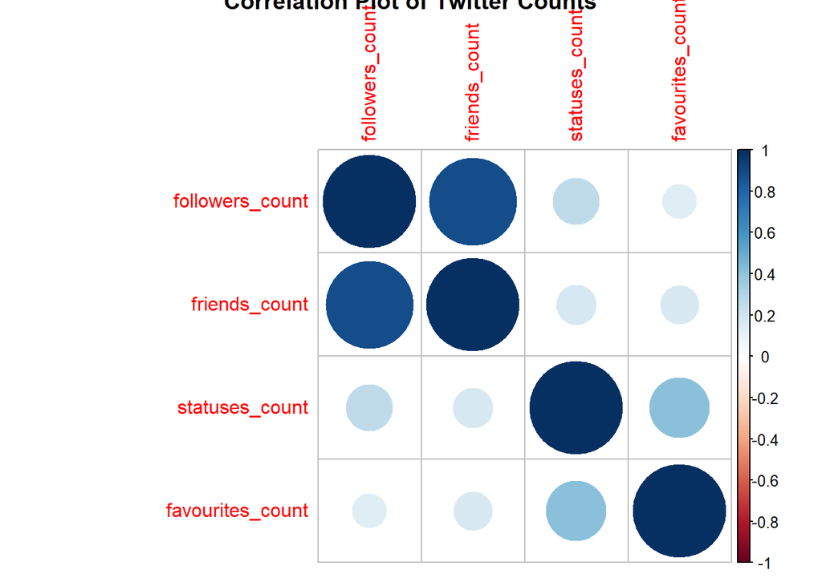

In this graph, we analyze the relation between the statuses_count and the favourites_count and divide the output into three groups Active, Normal and Passive. In general, it seems like Active Users tend to have a positive correlation between the number of statuses they have and the favorites count.

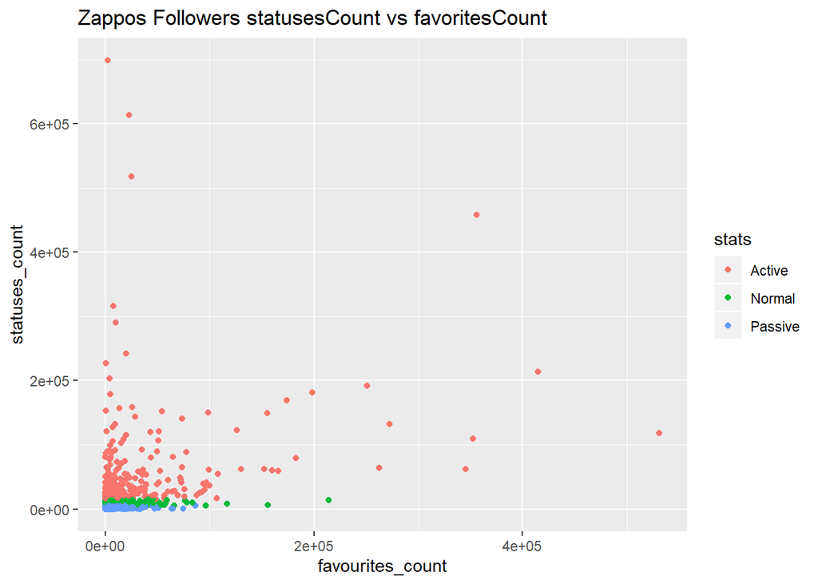

The next chart is a box plot to display the distribution of data based on a five number summary (“minimum”, first quartile (Q1), median, third quartile (Q3), and “maximum”). It shows outliers and what their values are. It can also tell you if the data is symmetrical, how tightly the data is grouped and how the data is skewed. We can see here that for normal and passive groups, the data is highly tighted. However, for the active group, the data is much more spread out around the median value as well as a lot of outliers showed off.

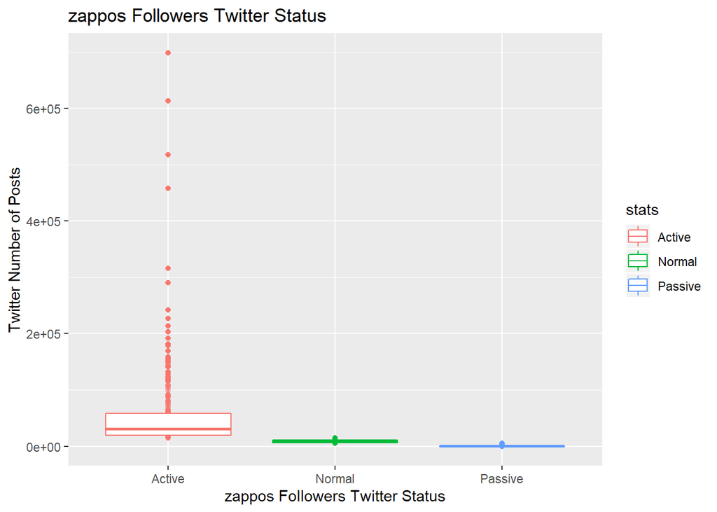

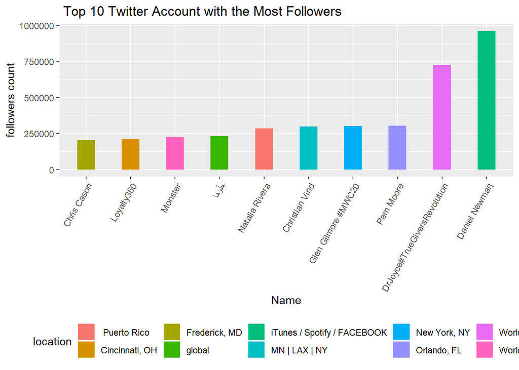

The next chart shows the Top 10 accounts from Zappos followers that have the most likes

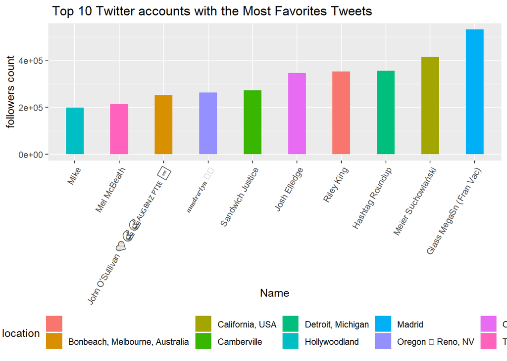

The next chart shows the top 10 Zappos followers accounts that follows the most number of people.

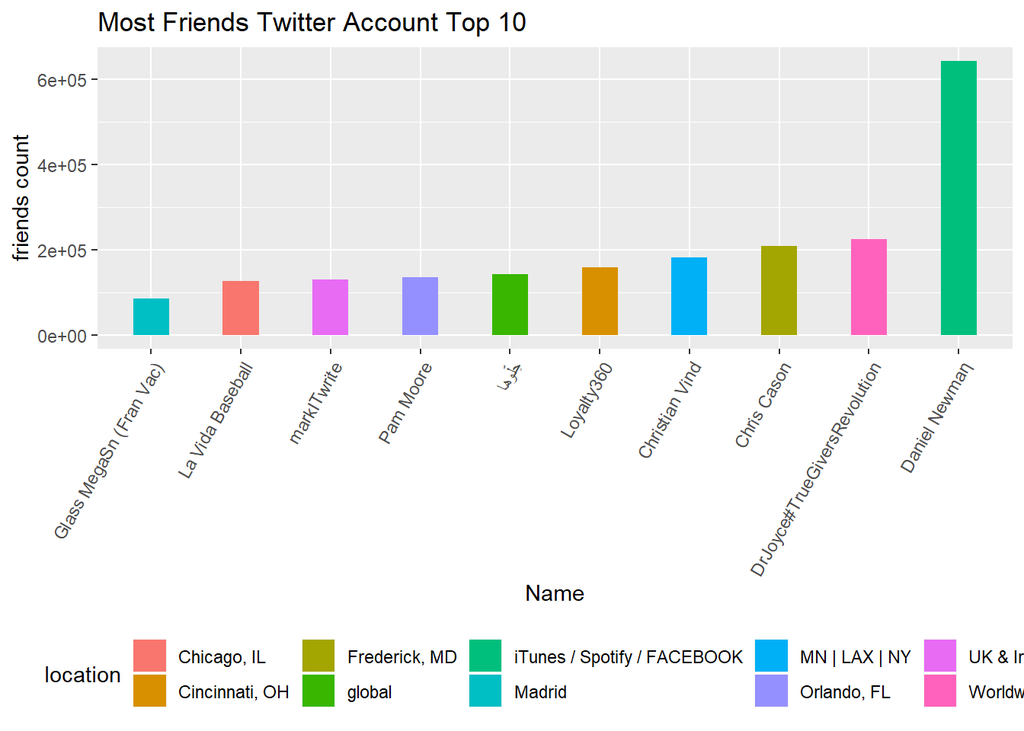

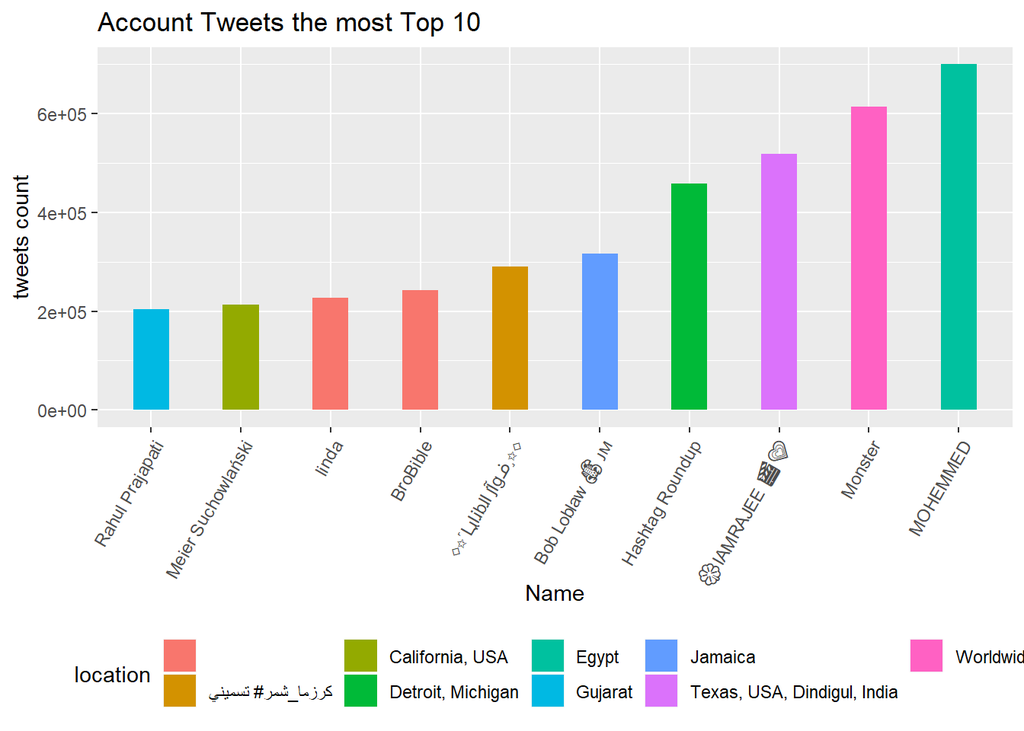

**Topic Analysis for Tweets made by Zappos Account:**

So we start by Investigating the Most Frequent terms: Top 20

The Most Frequent term happens to be US. Since Zappos is based in USA so it makes sense that the US could be their most frequent term when they tweet.

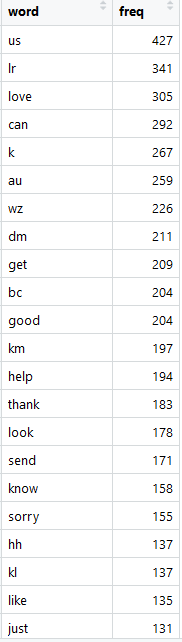

Another way to show the most frequent terms is by using word cloud. WordCloud is a technique to show which words are the most frequent among the given text

```
## # A tibble: 6 x 3
##   status_id           word                  n
##   <chr>               <chr>             <int>
## 1 1168956658728484864 blue                  1
## 2 1168956658728484864 can                   1
## 3 1168956658728484864 change                1
## 4 1168956658728484864 do                    1
## 5 1168956658728484864 httpstcozwyinxeyf     1
## 6 1168956658728484864 just                  1
```

```
## $delivery
## numeric(0)
```

```
## # A tibble: 6 x 2
##   word   freq
##   <chr> <int>
## 1 us      427
## 2 lr      341
## 3 love    305
## 4 can     292
## 5 k       267
## 6 au      259
```

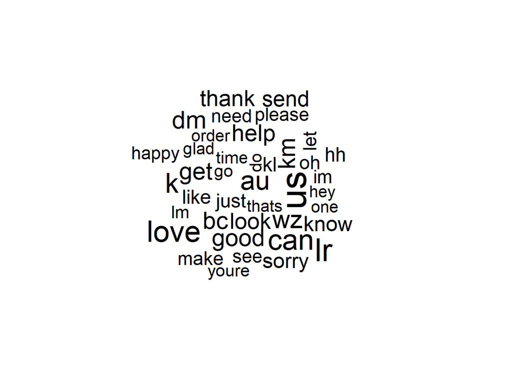

Next of, we need to find the K which is the number of topics we assume to be in the text. Using the FindTopicsNumber function and using Package ldatuning realizes 4 metrics to select perfect number of topics for LDA model. The 4 metrics used are Griffiths2004, CaoJuan2009, Arun2010 and Deveaud2014.

The most easy way is to calculate all metrics at once. All existing methods require to train multiple LDA models to select one with the best performance. It is computation intensive procedure and ldatuning uses parallelism.

```
## fit models... done.
## calculate metrics:
##   Griffiths2004... done.
##   CaoJuan2009... done.
##   Arun2010... done.
##   Deveaud2014... done.
```

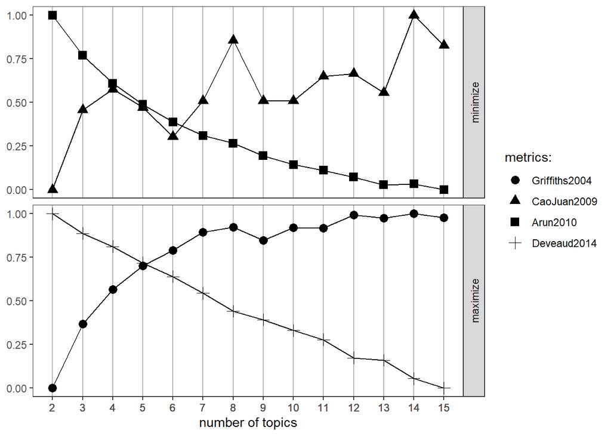

Now that we chose our K to be 3, we need to run the LDA model on our Document Term Matrix using Gibbs Sampling.

LDA is a mathematical method for estimating the following: finding the mixture of words that is associated with each topic, while also determining the mixture of topics that describes each document.

The LDA function returns an object containing the full details of the model fit, such as how words are associated with topics and how topics are associated with documents.

After fitting the model, we need to analyze the output. The tidytext package provides this method for extracting the per-topic-per-word probabilities, called β (“beta”).

```
## A LDA_Gibbs topic model with 3 topics.
```

```
## # A tibble: 24 x 3
##    topic term    beta
##    <int> <chr>  <dbl>
##  1     1 au    0.0330
##  2     1 wz    0.0292
##  3     1 good  0.0275
##  4     1 thank 0.0253
##  5     1 kl    0.0177
##  6     1 hh    0.0177
##  7     1 like  0.0176
##  8     1 youre 0.0117
##  9     2 lr    0.0428
## 10     2 love  0.0428
## # ... with 14 more rows
```

The following chart shows the top terms that are most common within each topic.

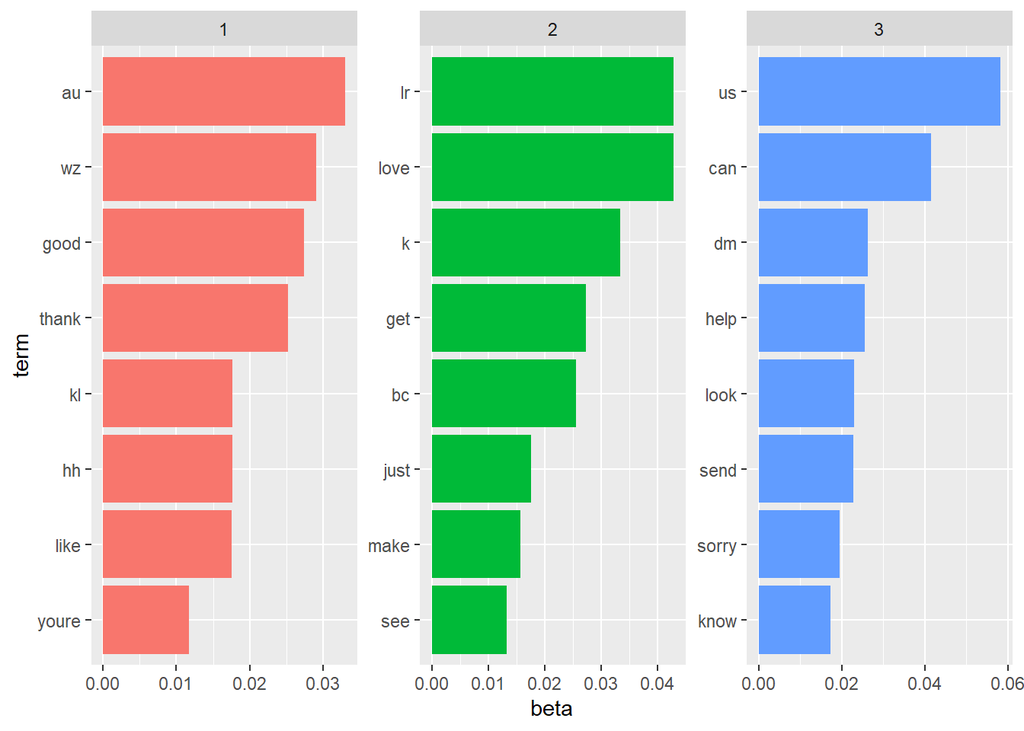

The most common words in topic 1 include “au”, “wz”, “good”, “thank”, and “like” which suggests it may represent the company’s emotional interaction with the clients over tweets. Those most common in topic 2 include “love”, “Lr”, “get”,”just” suggesting that this topic represents products promotions.The most common words for Topic 3 include words like “us”, “look”,”sorry”,”can” where it could leads that this topic speaks about customer service handling customers complains.

Document-topic probabilities analysis (GAMMA): Besides estimating each topic as a mixture of words, LDA also models each document as a mixture of topics. We can examine the per-document-per-topic probabilities, called γ (“gamma”), with the matrix = “gamma” argument to tidy().

```
## # A tibble: 3 x 2
##   topic nbr_documents
##   <int>         <int>
## 1     1          1029
## 2     2           813
## 3     3           625
```

So in total the following table shows how many documents fits unders which topic

**Topic Analysis for Tweets made by Twitter users on Zappos:**

In Topic Analysis, we figure out what a tweet is talking about. The topic model used in our case is Latent Dirichlet Allocation (LDA)

Latent Dirichlet Allocation (LDA) is a topic modelling algorithm used for extracting topics from a given collection of documents. It builds models in unsupervised mode so does not need labelled training data.

Based on the assumption that a document contains a mixture of N underlying different topics, and the document is generated by these topics with different proportions or probabilities, LDA is able to find out the topics and their relative proportions, which are distributed as a Latent Dirichlet random variable. The algorithm’s performance can be managed though assumptions on the word and topic distributions.

Given a pre-set of parameters such as α, which is the parameter of the Dirichlet prior on the per-document topic distributions and β, which is the parameter of the Dirichlet prior on the per-topic word distribution, the only required input is the documents and fixed topic number N (K). The output of LDA contains two parts. Part one is N topics with a list of words and count numbers for each word. Part two, for each document, indicates which topics it might belong to and the relative probability.

The general processing procedure using LDA is as follows: 1. Setting parameters. The default parameters are α = 0.1; β = 0.01; minTokenCount = 5; 2. Choose a topic number N or K and input data file. 3. Tokenize for the text data or column. 4. Run LDA algorithm to get the latent structure behind the text and print out the result

So we start by Investigating the Most Frequent terms: Top 20

The Most Frequent term happens to be Amazon. Since Amazon is the biggest retailer in the world so a reason of such association could be customers searching for a product on Amazon and might find it as well on Zappos so compare between them.

For the remaining terms a lot of them are other big brands in the US such as Disney,Ihop, Reblobster,RubyTuesday and one reason for that could be due to Partnerships or Sponsoships.

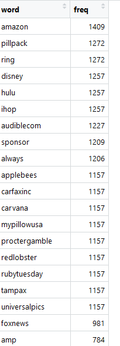

Another way to show the most frequent terms is by using word cloud. WordCloud is a technique to show which words are the most frequent among the given text

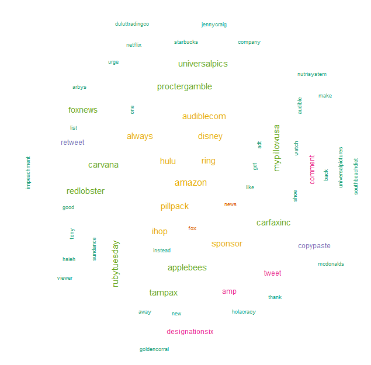

Next of, we need to find the K which is the number of topics we assume to be in the text. Using the FindTopicsNumber function and using Package ldatuning realizes 4 metrics to select perfect number of topics for LDA model. The 4 metrics used are Griffiths2004, CaoJuan2009, Arun2010 and Deveaud2014. The most easy way is to calculate all metrics at once. All existing methods require to train multiple LDA models to select one with the best performance. It is computation intensive procedure and ldatuning uses parallelism.

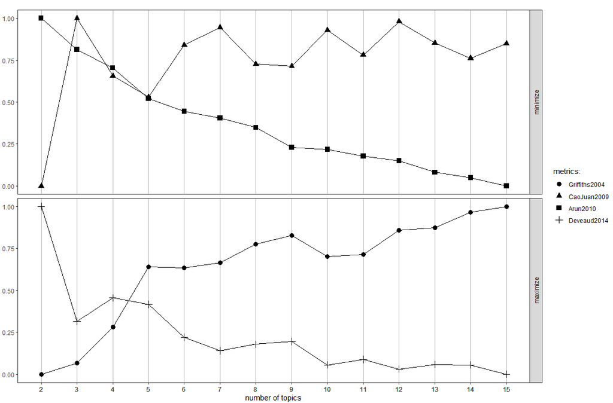

Now that we chose our K to be 3, we need to run the LDA model on our Document Term Matrix using Gibbs Sampling.

LDA is a mathematical method for estimating the following: finding the mixture of words that is associated with each topic, while also determining the mixture of topics that describes each document.

The LDA function returns an object containing the full details of the model fit, such as how words are associated with topics and how topics are associated with documents.

After fitting the model, we need to analyze the output. The tidytext package provides this method for extracting the per-topic-per-word probabilities, called β (“beta”).

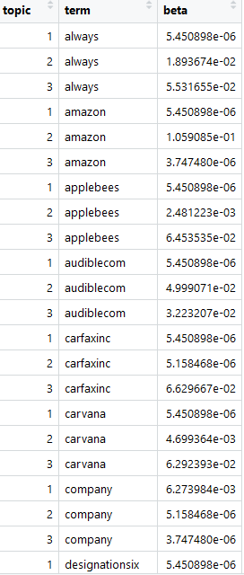

Notice that this has turned the model into a one-topic-per-term-per-row format. For each combination, the model computes the probability of that term being generated from that topic. For example, the term “amazon” has a 5.45 ×10−6 probability of being generated from topic 1, but a 1.05×10−1 probability of being generated from topic 2 and a 3.74x10-6 probability of being generated from topic 3.

The following chart shows the top terms that are most common within each topic.

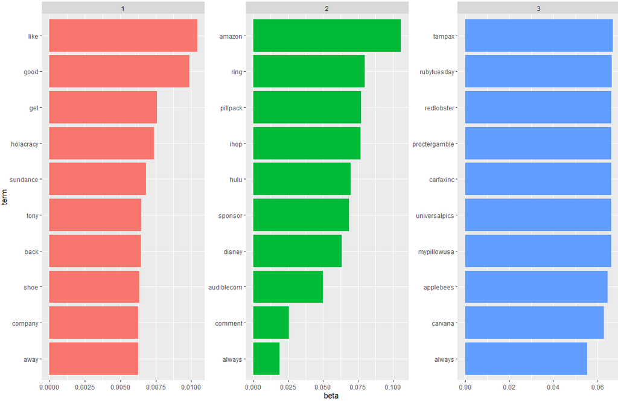

The most common words in topic 1 include “like”, “good”, “get”, “shoe”, and “company” which suggests it may represent customer’s satisfaction regarding the products specifically shoes. Those most common in topic 2 include “amazon”, “ihop”, “hulu”,”disney” suggesting that this topic represents comparison between Zappos and it’s competitors.The most common words for Topic 3 include words like “redlobster”, “rubytuesday”,”proctergamble”,”applebees” where it could leads that this topic speaks about promotions made by Zappos.

Document-topic probabilities analysis (GAMMA): Besides estimating each topic as a mixture of words, LDA also models each document as a mixture of topics. We can examine the per-document-per-topic probabilities, called γ (“gamma”), with the matrix = “gamma” argument to tidy().

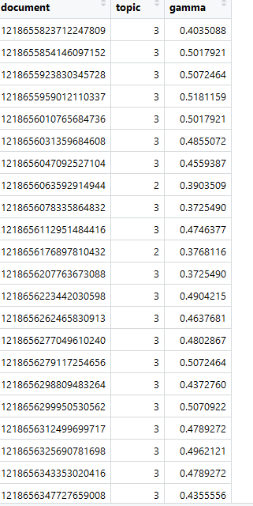

Each of these values is an estimated proportion of words from that document that are generated from that topic. For example, the model estimates that only about 43% of the words in document 1218656347727659008 were generated from topic 3.